# Sales Data Analysis Using R

Shoury Jain

2026-09-17

# Sales Data Analysis Using R

## Introduction

This project analyzes sales data using R.

The dataset contains information about products, categories, quantity sold, unit price, sales amount, and regions.

R is used to organize the data, perform statistical analysis, create graphs, and understand sales patterns.

### Objectives

- Create sales data
- Check and clean the data
- Perform statistical analysis
- Analyze product sales
- Compare regional sales
- Create graphs
- Interpret the results
- Identify important findings
- Give a conclusion

## Project Background

Sales analysis helps businesses understand their sales performance.

By analyzing sales data, we can compare products, quantities, prices, and different regions.

In this project, R is used to perform basic data analysis and visualization.

### Scope of the Project

This project focuses on 20 sales records.

The main variables are:

- Date
- Product
- Category
- Quantity
- Unit Price
- Region
- Sales

## 1. Create Sales Data

We create a sales dataset using the `data.frame()` function.

```r
sales <- data.frame(
  Date = c(
    "2026-01-05", "2026-01-08", "2026-01-12", "2026-01-18", "2026-01-23",
    "2026-02-03", "2026-02-09", "2026-02-15", "2026-02-21", "2026-02-27",
    "2026-03-04", "2026-03-10", "2026-03-16", "2026-03-22", "2026-03-28",
    "2026-04-05", "2026-04-11", "2026-04-17", "2026-04-23", "2026-04-29"
  ),
  Product = c(
    "Laptop", "Mouse", "Keyboard", "Monitor", "Headphones",
    "Laptop", "Mouse", "Keyboard", "Monitor", "Headphones",
    "Laptop", "Mouse", "Keyboard", "Monitor", "Headphones",
    "Laptop", "Mouse", "Keyboard", "Monitor", "Headphones"
  ),
  Category = c(
    "Electronics", "Accessories", "Accessories", "Electronics", "Accessories",
    "Electronics", "Accessories", "Accessories", "Electronics", "Accessories",
    "Electronics", "Accessories", "Accessories", "Electronics", "Accessories",
    "Electronics", "Accessories", "Accessories", "Electronics", "Accessories"
  ),
  Quantity = c(
    3, 15, 10, 6, 12,
    4, 18, 12, 7, 15,
    5, 20, 14, 8, 18,
    6, 22, 16, 9, 20
  ),
  Unit_Price = c(
    55000, 1200, 2200, 18000, 2500,
    55000, 1200, 2200, 18000, 2500,
    55000, 1200, 2200, 18000, 2500,
    55000, 1200, 2200, 18000, 2500
  ),
  Region = c(
    "North", "West", "South", "East", "West",
    "South", "North", "East", "West", "South",
    "East", "West", "North", "South", "East",
    "West", "South", "East", "North", "West"
  )
)

sales$Sales <- sales$Quantity * sales$Unit_Price

sales
```

```
##          Date    Product    Category Quantity Unit_Price Region  Sales
## 1  2026-01-05     Laptop Electronics        3      55000  North 165000
## 2  2026-01-08      Mouse Accessories       15       1200   West  18000
## 3  2026-01-12   Keyboard Accessories       10       2200  South  22000
## 4  2026-01-18    Monitor Electronics        6      18000   East 108000
## 5  2026-01-23 Headphones Accessories       12       2500   West  30000
## 6  2026-02-03     Laptop Electronics        4      55000  South 220000
## 7  2026-02-09      Mouse Accessories       18       1200  North  21600
## 8  2026-02-15   Keyboard Accessories       12       2200   East  26400
## 9  2026-02-21    Monitor Electronics        7      18000   West 126000
## 10 2026-02-27 Headphones Accessories       15       2500  South  37500
## 11 2026-03-04     Laptop Electronics        5      55000   East 275000
## 12 2026-03-10      Mouse Accessories       20       1200   West  24000
## 13 2026-03-16   Keyboard Accessories       14       2200  North  30800
## 14 2026-03-22    Monitor Electronics        8      18000  South 144000
## 15 2026-03-28 Headphones Accessories       18       2500   East  45000
## 16 2026-04-05     Laptop Electronics        6      55000   West 330000
## 17 2026-04-11      Mouse Accessories       22       1200  South  26400
## 18 2026-04-17   Keyboard Accessories       16       2200   East  35200
## 19 2026-04-23    Monitor Electronics        9      18000  North 162000
## 20 2026-04-29 Headphones Accessories       20       2500   West  50000
```

### Dataset Description

The dataset contains 20 sales records.

The variables used in the dataset are:

- **Date:** Date of the sale
- **Product:** Name of the product
- **Category:** Product category
- **Quantity:** Number of units sold
- **Unit Price:** Price of one unit
- **Region:** Sales region
- **Sales:** Total sales amount

## 2. Check the Data

We use `summary()` to get a basic overview of the dataset.

```r
summary(sales)
```

```
##         Date         Product        Category     Quantity       Unit_Price
##  Length   :20   Length   :20   Length   :20   Min.   : 3.00   Min.   : 1200
##  N.unique :20   N.unique : 5   N.unique : 2   1st Qu.: 6.75   1st Qu.: 2200
##  N.blank  : 0   N.blank  : 0   N.blank  : 0   Median :12.00   Median : 2500
##  Min.nchar:10   Min.nchar: 5   Min.nchar:11   Mean   :12.00   Mean   :15780
##  Max.nchar:10   Max.nchar:10   Max.nchar:11   3rd Qu.:16.50   3rd Qu.:18000
##                                               Max.   :22.00   Max.   :55000
##        Region       Sales
##  Length   :20   Min.   : 18000
##  N.unique : 4   1st Qu.: 26400
##  N.blank  : 0   Median : 41250
##  Min.nchar: 4   Mean   : 94845
##  Max.nchar: 5   3rd Qu.:148500
##                 Max.   :330000
```

The summary provides information about the numerical variables in the dataset.

## 3. Check Dataset Structure

The `str()` function is used to understand the structure of the dataset.

```r
str(sales)
```

```
## 'data.frame':    20 obs. of  7 variables:
##  $ Date      : chr  "2026-01-05" "2026-01-08" "2026-01-12" "2026-01-18" ...
##  $ Product   : chr  "Laptop" "Mouse" "Keyboard" "Monitor" ...
##  $ Category  : chr  "Electronics" "Accessories" "Accessories" "Electronics" ...
##  $ Quantity  : num  3 15 10 6 12 4 18 12 7 15 ...
##  $ Unit_Price: num  55000 1200 2200 18000 2500 55000 1200 2200 18000 2500 ...
##  $ Region    : chr  "North" "West" "South" "East" ...
##  $ Sales     : num  165000 18000 22000 108000 30000 220000 21600 26400 126000 37500 ...
```

This helps us understand the number of observations, variables, and their data types.

## 4. Check Missing Values and Duplicates

We check whether the dataset contains missing values or duplicate records.

```r
colSums(is.na(sales))
```

```
##       Date    Product   Category   Quantity Unit_Price     Region      Sales
##          0          0          0          0          0          0          0
```

```r
sum(duplicated(sales))
```

```
## [1] 0
```

The dataset contains no missing values and no duplicate records.

Therefore, the data is ready for analysis.

## 5. Basic Statistical Analysis

We calculate important statistics for quantity and sales.

```r
mean(sales$Quantity)
```

```
## [1] 12
```

```r
max(sales$Quantity)
```

```
## [1] 22
```

```r
min(sales$Quantity)
```

```
## [1] 3
```

```r
mean(sales$Sales)
```

```
## [1] 94845
```

```r
max(sales$Sales)
```

```
## [1] 330000
```

```r
min(sales$Sales)
```

```
## [1] 18000
```

These values help us understand the average, highest, and lowest sales performance.

## 6. Total Sales

We calculate the total sales from all records.

```r
total_sales <- sum(sales$Sales)

total_sales
```

```
## [1] 1896900
```

The total sales represent the overall sales amount recorded in the dataset.

## 7. Sales by Product

We calculate total sales for each product.

```r
product_sales <- aggregate(
  Sales ~ Product,
  data = sales,
  FUN = sum
)

product_sales
```

```
##      Product  Sales
## 1 Headphones 162500
## 2   Keyboard 114400
## 3     Laptop 990000
## 4    Monitor 540000
## 5      Mouse  90000
```

This table helps compare the sales performance of different products.

### Product Sales Graph

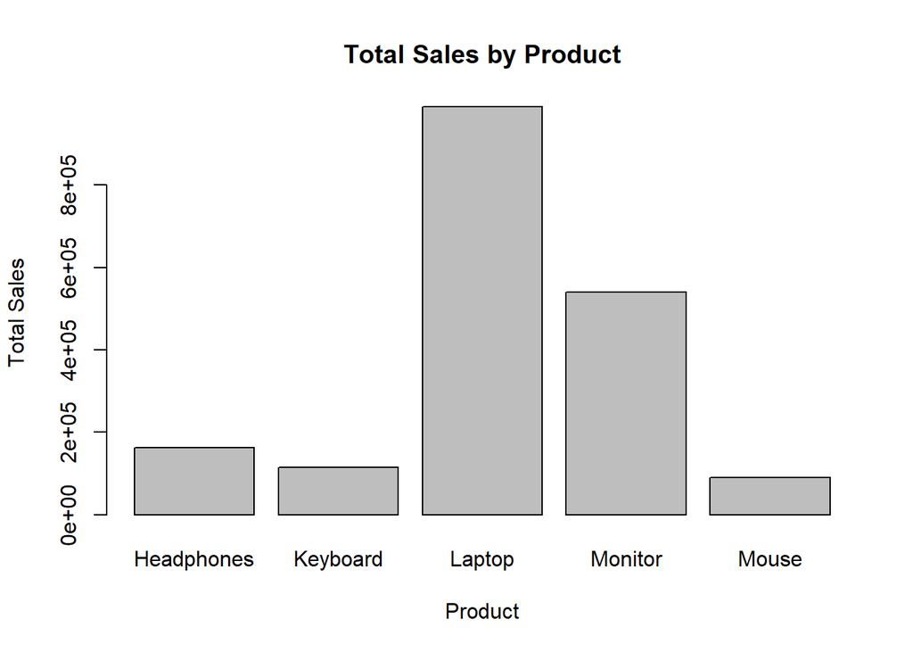

```r
barplot(
  product_sales$Sales,
  names.arg = product_sales$Product,
  main = "Total Sales by Product",
  xlab = "Product",
  ylab = "Total Sales"
)
```

The graph provides a visual comparison of total sales between different products.

## 8. Quantity Sold by Product

We calculate the total quantity sold for each product.

```r
product_quantity <- aggregate(
  Quantity ~ Product,
  data = sales,
  FUN = sum
)

product_quantity
```

```
##      Product Quantity
## 1 Headphones       65
## 2   Keyboard       52
## 3     Laptop       18
## 4    Monitor       30
## 5      Mouse       75
```

### Quantity Sold Graph

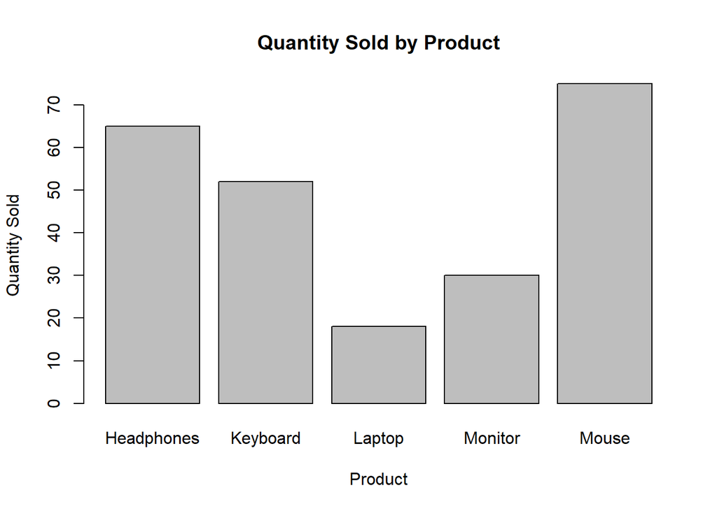

```r
barplot(
  product_quantity$Quantity,
  names.arg = product_quantity$Product,
  main = "Quantity Sold by Product",
  xlab = "Product",
  ylab = "Quantity Sold"
)
```

The graph shows the number of units sold for each product.

## 9. Sales by Region

We calculate total sales for each region.

```r
region_sales <- aggregate(
  Sales ~ Region,
  data = sales,
  FUN = sum
)

region_sales
```

```
##   Region  Sales
## 1   East 489600
## 2  North 379400
## 3  South 449900
## 4   West 578000
```

### Regional Sales Graph

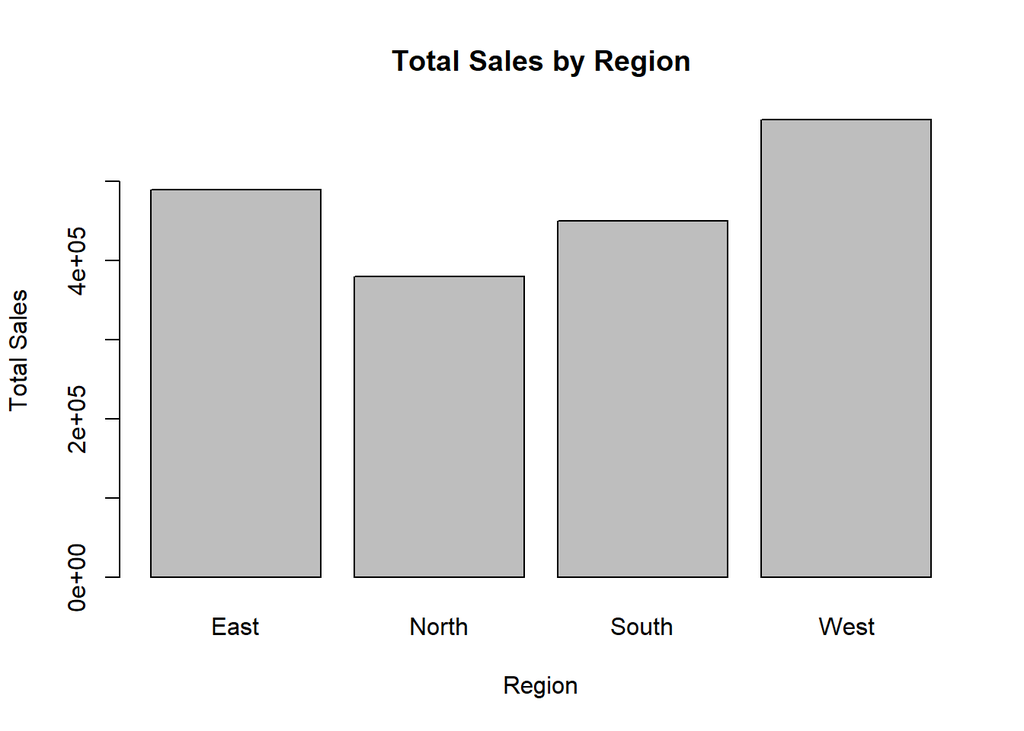

```r
barplot(
  region_sales$Sales,
  names.arg = region_sales$Region,
  main = "Total Sales by Region",
  xlab = "Region",
  ylab = "Total Sales"
)
```

The graph helps compare sales performance across regions.

## 10. Average Sales by Product

We calculate the average sales for each product.

```r
average_product_sales <- aggregate(
  Sales ~ Product,
  data = sales,
  FUN = mean
)

average_product_sales
```

```
##      Product  Sales
## 1 Headphones  40625
## 2   Keyboard  28600
## 3     Laptop 247500
## 4    Monitor 135000
## 5      Mouse  22500
```

This analysis helps us understand the average sales generated by different products.

## 11. Quantity vs Sales

A scatter plot is used to understand the relationship between quantity sold and sales.

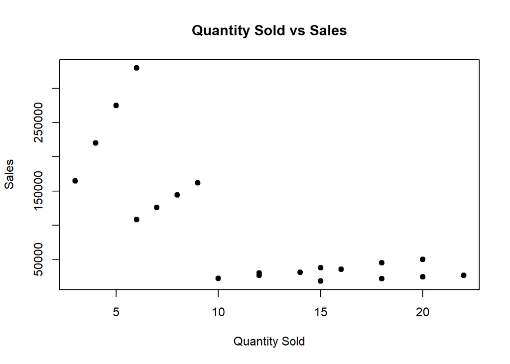

```r
plot(
  sales$Quantity,
  sales$Sales,
  main = "Quantity Sold vs Sales",
  xlab = "Quantity Sold",
  ylab = "Sales",
  pch = 19
)
```

The graph shows the relationship between the number of units sold and the sales amount.

## 12. Unit Price vs Sales

We compare unit price with total sales.

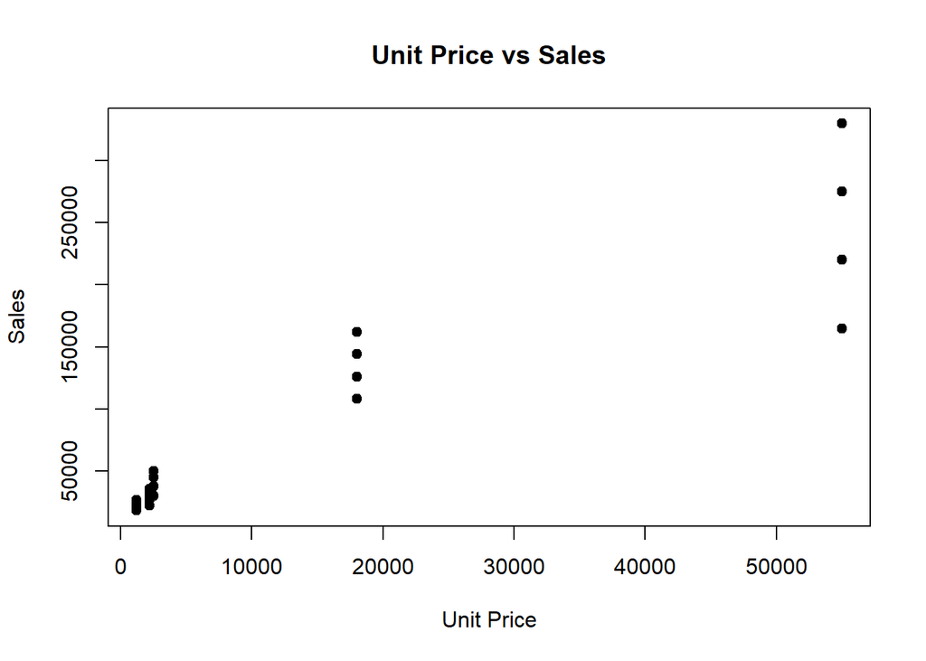

```r
plot(
  sales$Unit_Price,
  sales$Sales,
  main = "Unit Price vs Sales",
  xlab = "Unit Price",
  ylab = "Sales",
  pch = 19
)
```

The graph helps us understand the relationship between unit price and sales.

## 13. Correlation Analysis

Correlation helps us understand the relationship between quantity sold and sales.

```r
cor(sales$Quantity, sales$Sales)
```

```
## [1] -0.7544828
```

## 14. Highest Sales Record

We identify the record with the highest sales.

```r
sales[which.max(sales$Sales), ]
```

```
##          Date Product    Category Quantity Unit_Price Region  Sales
## 16 2026-04-05  Laptop Electronics        6      55000   West 330000
```

This gives information about the product, quantity, price, region, and sales amount of the highest sales record.

## 15. Lowest Sales Record

We identify the record with the lowest sales.

```r
sales[which.min(sales$Sales), ]
```

```
##         Date Product    Category Quantity Unit_Price Region Sales
## 2 2026-01-08   Mouse Accessories       15       1200   West 18000
```

This identifies the record with the lowest sales amount.

## 16. Interpretation of Results

The analysis provides several observations.

- Different products generate different sales amounts.
- Sales performance varies between regions.
- Quantity sold has a relationship with total sales.
- Product-wise analysis helps compare products.
- Regional analysis helps compare different regions.
- Graphs make the sales data easier to understand.

The results are based on the sample dataset used in this project.

## 17. Key Findings

The main findings are:

- Total sales can be calculated using `sum()`.
- Product sales can be compared using `aggregate()`.
- Regional sales can be compared using a bar graph.
- Quantity sold can be analyzed using statistical functions.
- Highest and lowest sales records can be identified.
- Graphs provide a visual representation of sales data.
- The dataset has no missing values.
- The dataset has no duplicate records.

## 18. Limitations

This project has some limitations.

- The dataset contains only 20 records.
- Only a limited number of products are included.
- Only four regions are considered.
- Customer information is not included.
- Profit and expenses are not included.
- The dataset is a small sample.

Therefore, the results should be interpreted according to the available data.

## 19. Future Scope

The project can be improved by using a larger dataset.

Additional information could include:

- Customer details
- Profit
- Discount
- Salesperson
- Monthly sales
- Customer ratings
- Payment method

Advanced statistical methods and machine learning could also be used for future sales prediction.

## 20. Conclusion

This project analyzed sales data using R.

The project demonstrated how to create a dataset, check its structure, identify missing values and duplicates, perform statistical analysis, and create graphs.

Product-wise and region-wise analysis helped us understand different aspects of sales performance.

Overall, R provides useful tools for data analysis, visualization, and interpretation of sales data.

## Final Summary

In this project, we learned how to:

- Create a dataset
- Check data structure
- Check missing values
- Check duplicate records
- Calculate statistics
- Calculate total sales
- Analyze products
- Analyze regions
- Create bar graphs
- Create scatter plots
- Calculate correlation
- Interpret results
- Identify findings
- Discuss limitations
- Suggest future improvements